# DS108-03-07 - NoSQL - Lesson 3 Practice Hands-On

For your Lesson 3 Practice Hands-On, you will be working with your new knowledge on NoSQL. **This Hands-On will not be graded**, but we encourage you to complete it. The best way to become great at working with databases is to practice! Once you have submitted your project, you will be able to access the solution on the next page.

> [!caution] To Submit Be sure to zip and submit your `NoSQL-HandsOn3` text document when finished! You will not be able to re-submit, so be sure the screenshots to each part are located within this document.

## Requirements

This Hands-On is structured into *two* parts, and each part may ask you to run multiple queries. After each query, please take a screenshot and add it to a text document (or an equivalent) and name this file `NoSQL-HandsOn3`. This way, you will be able to submit your answers to each part all at once. You will continue working with the `inventory` collection in Atlas that you created during the last lessons. Good luck!

# Part 1

Within your `inventory` collection, run queries to accomplish the following:

## 1.1 Update the item of `journal` to have a height of 16.

[figure not shown]

```json
db.inventory.update({ item: "journal" },
{ $set : { "size.h" : 16 }})

db.inventory.find({ item: "journal" })
```

## 1.2 Update all items with a status of `D` to have a quantity of 50.

[figure not shown]

```json
db.inventory.updateMany({ status: "D" }, { $set: { qty: 50 }})

db.inventory.find({ status: "D" })
```

## 1.3 Update the item `paper` to include a field `rating` that has the value of `4 stars` and change its status to `A`.

[figure not shown]

```json
db.inventory.update({ item: "paper" },
{ $set: { "rating" : "4 stars"}},
{ upsert: true })

db.inventory.update({ item: "paper" },
{ $set: { "status" : "A" }})

db.inventory.find({ item: "paper" })
```

## 1.4 Update all items to change the `h` and `w` fields to be `height` and `width`.

[figure not shown]

```json
db.inventory.updateMany({ },
{ $rename: { "size.h" : "size.height",
             "size.w" : "size.width" }})

db.inventory.find()
```

## 1.5 Update the item `spiral notebook` so that the `height` and `width` is incremented by 2.

[figure not shown]

```json
db.inventory.update({ item: "spiral notebook" },
{ $inc: { "size.height" : 2 , "size.width" : 2 }})

db.inventory.find({ item: "spiral notebook" })
```

## 1.6a Update the items `paper` to multiply the `height` by 3.

[figure not shown]

[figure not shown]

```json
db.inventory.find({ item: "paper" })

db.inventory.update({ item: "paper" },
{ $mul: { "size.height" : 3 }})

db.inventory.find({ item: "paper" })
```

## 1.6b Update the item `day planner` to multiply the `height` by 3.

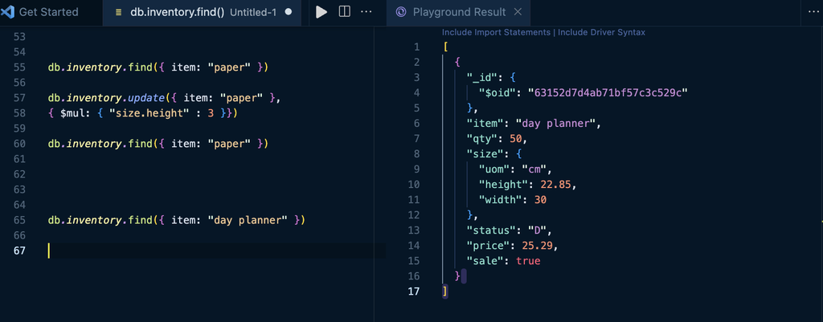

[figure not shown]

```json
db.inventory.find({ item: "day planner" })

db.inventory.update({ item: "day planner" },
{ $mul: { "size.height" : 3 }})

db.inventory.find({ item: "day planner" })
```

# Part 2

For the second part, you will be working through a word problem and you will need a bit more information. Please run the following query to add documents into your inventory collection then complete the below requirements:

```json
db.inventory.insertMany([
  {
    item: 'sticky note pads',
    size: { height: 8.9, width: 9, uom: 'cm' },
    status: 'B',
    quantity: 5
  },
  {
    item: 'pens',
    size: { height: 12, width: 1.3, uom: 'cm' },
    status: 'A',
    quantity: 4
  },
  {
    item: 'pencils',
    size: { height: 13, width: 1.4, uom: 'cm' },
    status: 'D',
    quantity: 10
  },
  {
    item: 'clipboard',
    size: { height: 13, width: 7, uom: 'in' },
    status: 'B',
    quantity: 2
  },
  {
    item: 'printer ink',
    size: { height: 2, width: 3, uom: 'in' },
    status: 'C',
    quantity: 2
  }
]);
```

The company you are working for wants to update their `inventory` database. Currently, there are ten pieces of inventory in the database.

## 2.1 Update Inventory Rating

They want to give each product a rating of 4 stars to start, as well as a field that shows if it has been rated yet using a boolean. They would like this to be reflected in the database as `rating` with two fields: `numberOfStars`, and `hasBeenRated`.

[figure not shown]

```json
db.inventory.find()

db.inventory.update({ item: "paper" },
{ $unset: { "rating" : "" } })

db.inventory.find({ item: "paper" })


db.inventory.updateMany({ },
{ $set: { "rating.numberOfStars" : "4 stars" ,
"rating.hasBeenRated" : true }},
{ upsert: true })

db.inventory.find()
```

## 2.2 Double Inventory Quantity

Also, they want to double the quantity of every product since the company is rapidly growing.

[figure not shown]

```json
db.inventory.updateMany({ },
{ $mul: { "qty" : 2 }})

db.inventory.find()
```

## 2.3 Update Inventory Status

Lastly, they would like you to find all products that are sized using centimeters and give them a status of “B”.

[figure not shown]

[figure not shown]

```json
db.inventory.find({ "size.uom" : "cm" })

db.inventory.updateMany({ "size.uom" : "cm" },
{ $set: { "status" : "B" }})

db.inventory.find()
```